# Describing the Relationship Between Weekly Earnings and Time Spent on Eldercare

Vanellsa Acha, Victoria Do, Javier Mendoza

2024-07-20

## Introduction:

With an aging population and the escalating cost of healthcare, understanding the relationship between income and time spent on elder care is increasingly important. This study explores whether individuals with different income levels vary in their care giving responsibilities. Investigating this relationship sheds light on the economic and social dynamics that caregivers encounter, revealing how financial capacity and household structure impact elder care. This analysis aims to provide insights into the challenges and resources available to family caregivers, contributing to a deeper understanding of the pressures faced by those providing care. By examining these factors, we hope to inform policies and support systems that can better address the needs of caregivers in our society.

## The Research Question

(**What is the relationship between the number of minutes spent caring for aged adults and income?**)

## Data Source

The data for this analysis is sourced from the American Time Use Survey (ATUS), which is sponsored by the Bureau of Labor Statistics and conducted by the U.S. Census Bureau. The ATUS is a nationally representative survey that samples individuals from households that have completed their final month of interviews for the Current Population Survey (CPS). Participants are asked to provide a detailed 24-hour diary of their activities from 4 a.m. on the previous day until 4 a.m. on the interview day. Data collection is carried out through telephone interviews by trained interviewers who ask respondents to recall and describe their activities, including start and end times, locations, and accompanying persons. Each respondent provides a single day’s worth of time use data, making individuals the primary units of observation. The survey also gathers demographic, employment, and household information, facilitating comprehensive analyses of time use patterns across different population groups. Key features of the ATUS data include unique identifiers (TUCASEID and TULINENO) for each household and individual, ensuring anonymity and facilitating data linkage; TRTEC, which measures the total time spent providing elder care in minutes; TRERNWA, which records weekly earnings at the main job with two implied decimals, indicating financial capacity; and statistical weights to ensure the representatives of survey results, accounting for the complex sampling design and response rates.

## Data Wrangling

The data set was filtered to include only valid entries for key variables: total time spent providing elder care (TRTEC), weekly earnings (TRERNWA), presence of children (TRHHCHILD), full-time/part-time status (TRDPFTPT), total hours worked (TEHRUSLT), and presence of a partner (TRSPPRES). Invalid values were removed, and transformations were applied to convert weekly earnings to actual dollar amounts and log-transform skewed variables for our second model. Specifically, TRERNWA was divided by 100 and then log-transformed, while TRTEC and TEHRUSLT were also log-transformed. The presence of a partner was re-coded into two categories (“Partner Present” and “No Partner Present”). This process reduced our data set from 8,387 row and 165 columns to a final data set of 163 rows and 14 columns, ensuring that the analysis is based on accurate and reliable data.

## Operationalization

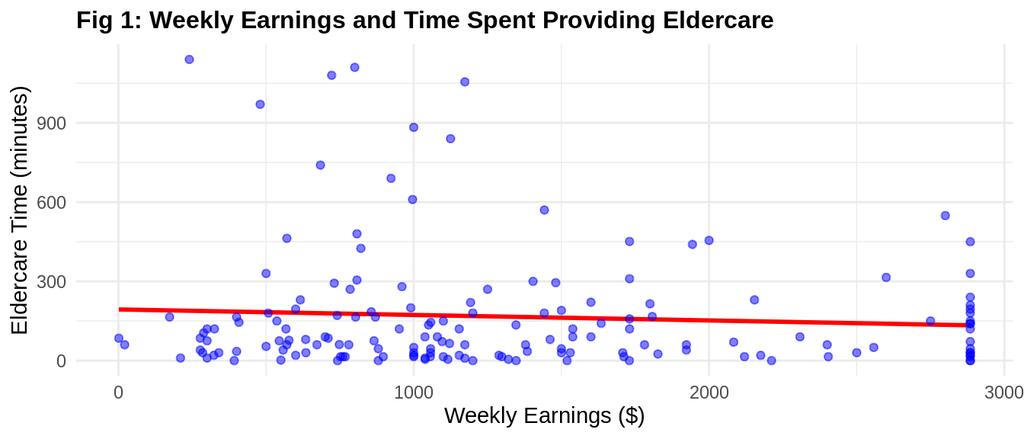

The plot shows that there is a slight negative trend indicating that higher weekly earnings are associated with slightly less time spent on eldercare, though the relationship appears weak and dispersed.

## Model Assumptions

The assumptions for our large-sample linear model include independent and identically distributed (IID) sampled data, the existence of a unique Best Linear Predictor (BLP), and homoscedasticity. The ATUS data’s stratified random sampling supports the IID assumption, ensuring each observation is independent and identically distributed, though slight dependencies may exist due to household dynamics. The existence of a unique BLP is supported by the absence of infinite variances and heavy tail distributions, and by the lack of perfect collinearity among input variables such as “Weekly Earnings,” “Presence of Children,” and “Presence of Spouse.” However, multicollinearity still needs monitoring. Homoscedasticity, requiring consistent variability in the dependent variable across all levels of the independent variable, shows some violations, as scatter plots suggest heteroscedasticity. Logarithmic transformations of earnings and caregiving time address this issue partially, indicating further refinement is needed.

## Model Specification

For this study, we specified a set of regression models to describe the relationship between weekly earnings and time spent providing eldercare. Logarithmic transformations were applied to variables like weekly earnings and caregiving time to address skewness and ensure a more linear relationship. Additional factors such as the presence of children and a spouse were incorporated into the models to account for household dynamics. These transformations were chosen to normalize the skewed distributions of the original variables, providing a clearer understanding of the joint distribution. Ordinal variables were appropriately converted to factors to avoid treating them as metric, ensuring accurate representation in the analysis.

## Model Results and Interpretation

The model tested three variables: log-transformed weekly earnings (log_TRERNWA), presence of children in the household (TRHHCHILD), and presence of a spouse (TRSPPRES). The coefficient for log-transformed weekly earnings was -0.03005, which is not statistically significant (p = 0.820), indicating that income does not significantly impact eldercare time. In contrast, the presence of children in the household had a coefficient of 1.04513 (p = 0.000465), showing practical significance, with households having children spending approximately 2.84 times more time on eldercare (exp(1.04513) ≈ 2.84). Additionally, the presence of a spouse had a coefficient of 0.22942 (p = 0.066), which suggests a marginally significant trend where households with a spouse present might spend about 26% more time on eldercare (exp(0.22942) ≈ 1.26). Overall, while income does not significantly affect eldercare time, the presence of children in the household significantly increases the time dedicated to eldercare, highlighting the compounded caregiving responsibilities in such households. These findings suggest that policies supporting caregivers should consider the household composition, especially focusing on those with children, to effectively address caregiving challenges.

## Appendix

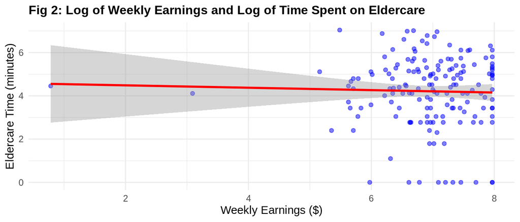

The fitted regression line shows a slight negative relationship, indicating that higher earnings are associated with marginally less time spent on eldercare, but the effect is weak and not practically significant.

### Distribution of Time Spent of Eldercare vs Weekly Earnings

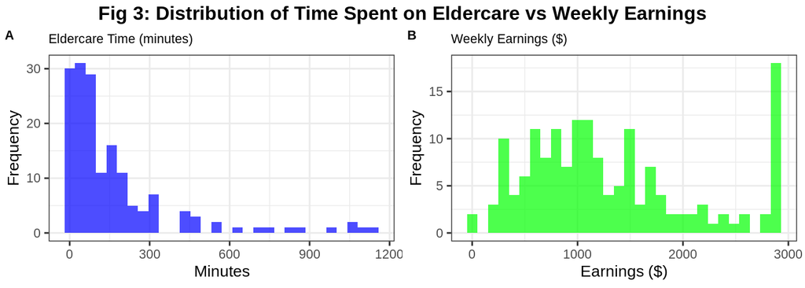